# Lab 9 - Multiple Linear Regression

Gracie White

Use this template to follow along in Lab Week 9. Each code chunk you’ll need is already created and named.

**Lab 9 Objectives:**

- Explore multivariate data (SLO housing prices)
- Perform multiple linear regression
- Assess diagnostics
- Compare different models by AIC
- Explain model outputs
- Make a nice table of regression results
- Make predictions using a final model
- Visualize predictions with original data

### 1. Load packages

- tidyverse
- stargazer

### 2. Load data (slo_homes.csv) as a df called ‘homes’, then filter to create a data frame called ‘homes_sub’ that only include homes in SLO, Arroyo Grande, Santa Maria-Orcutt, and Atascadero

### 3. Go exploring (visual) + think critically about variables

*Note: It’s OK to LOOK at things separately, even if you’re including all in a model together!*

Example: if we want to compare distribution of housing prices by CITY (ignoring all other variables), we can do that:

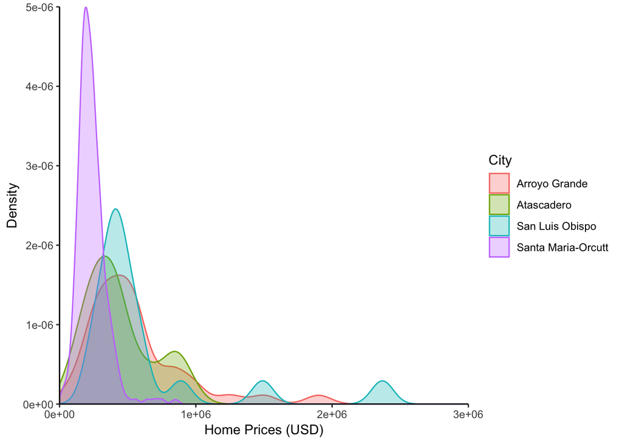

```r
# a. Calculate mean price by city
mean_by_city <- homes_sub %>%
  group_by(City) %>%
  summarize(
    mean = mean(Price)
  )

# b. Visualize prices by city
by_city <- ggplot(homes_sub, aes(x = Price)) +
  geom_density(aes(color = City, fill = City), alpha = 0.3) + # Note: just to show what the geom_violin shows
  theme_classic() +
  scale_x_continuous(expand = c(0,0), limits = c(0,3e6)) +
  scale_y_continuous(expand = c(0,0)) +
  labs(x = "Home Prices (USD)", y = "Density")

by_city
```

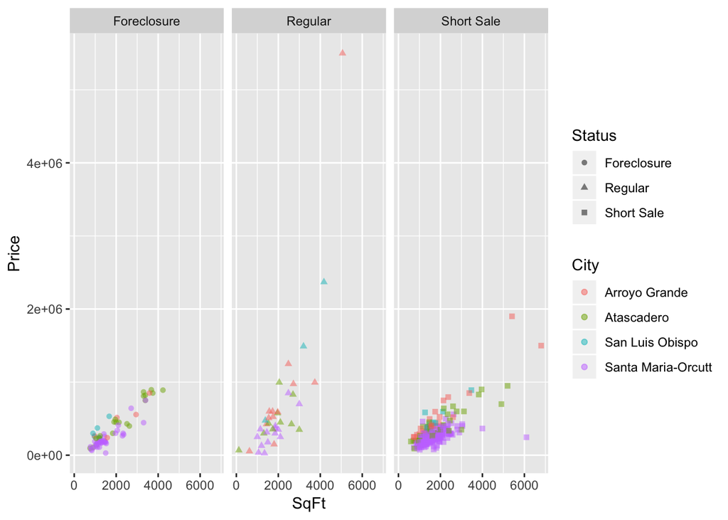

```r
# a. Relationship between square footage and price
by_sqft <- ggplot(homes_sub, aes(x = SqFt, y = Price)) +
  geom_point(aes(color = City, pch = Status), alpha = 0.5) +
  facet_wrap(~Status)

by_sqft
```

```r
# Observations here: Does relationship appear ~ linear? Anything else we can pick out re: trends, outliers, etc.? What is the general trend? Any outliers? Is there reason enough for us to omit it?
```

### 4. Multiple linear regression

Multiple linear regression in R follows the same syntax we’ve been using so far:

```
lm(y ~ x1 + x2 + x3..., data = df_name)
```

Let’s try this model a couple of different ways:

1. Use all available variables (saturated model)
2. Use only SqFt as a predictor for “home size” generally (omit Bathrooms and Bedrooms), and omit PricePerSqFt (since it’s derived from two other existing variables in the model)

Use summary() to view the model output and statistics.

```r
# a. Saturated model:

homes_lm1 <- lm(Price ~ City + Bedrooms + Bathrooms + SqFt + PricePerSqFt + Status, data = homes_sub)
#this is bad because price per sqft is calulated from dependant variable price. Biased overfitting of model results!
homes_lm1
```

```
##
## Call:
## lm(formula = Price ~ City + Bedrooms + Bathrooms + SqFt + PricePerSqFt +
##     Status, data = homes_sub)
##
## Coefficients:
##            (Intercept)          CityAtascadero     CitySan Luis Obispo
##              -626690.9                 -9068.2                -76863.0
## CitySanta Maria-Orcutt                Bedrooms               Bathrooms
##               120160.7                -30792.8                 27998.7
##                   SqFt            PricePerSqFt           StatusRegular
##                  230.7                  2962.8                -19792.3
##       StatusShort Sale
##               -41575.7
```

```r
# b. Model summary:
```

The next model: Exclude price per square foot, and bedrooms/bathrooms (since these are largely explained by square footage…)

```r
# a. Updated model with variables City, SqFt, and Status:

homes_lm2 <- lm(Price ~ City + SqFt + Status, data = homes_sub)
homes_lm2
```

```
##
## Call:
## lm(formula = Price ~ City + SqFt + Status, data = homes_sub)
##
## Coefficients:
##            (Intercept)          CityAtascadero     CitySan Luis Obispo
##               106333.1               -202157.5                 34525.4
## CitySanta Maria-Orcutt                    SqFt           StatusRegular
##              -275841.3                   245.9                209998.9
##       StatusShort Sale
##                 2282.4
```

```r
# b. Model summary:

summary(homes_lm2)
```

```
##
## Call:
## lm(formula = Price ~ City + SqFt + Status, data = homes_sub)
##
## Residuals:
##      Min       1Q   Median       3Q      Max
## -1087480   -68268     8241    62660  3938242
##
## Coefficients:
##                          Estimate Std. Error t value Pr(>|t|)
## (Intercept)             106333.12   57574.57   1.847   0.0655 .
## CityAtascadero         -202157.51   49077.01  -4.119 4.63e-05 ***
## CitySan Luis Obispo      34525.41   70837.96   0.487   0.6263
## CitySanta Maria-Orcutt -275841.28   42992.76  -6.416 4.00e-10 ***
## SqFt                       245.93      15.33  16.048  < 2e-16 ***
## StatusRegular           209998.86   49636.98   4.231 2.90e-05 ***
## StatusShort Sale          2282.42   32894.07   0.069   0.9447
## ---
## Signif. codes:  0 '***' 0.001 '**' 0.01 '*' 0.05 '.' 0.1 ' ' 1
##
## Residual standard error: 243100 on 396 degrees of freedom
## Multiple R-squared:  0.5339, Adjusted R-squared:  0.5268
## F-statistic:  75.6 on 6 and 396 DF,  p-value: < 2.2e-16
```

Wait…but what if I wanted everything to be with respect to a Regular sale status? Then I need to change my factor levels. We’ve done this before, here we’ll use a different function (fct_relevel) from *forcats* package in the tidyverse.

```r
# a. Set Status to class 'factor'
homes_sub$Status <- factor(homes_sub$Status)

# b. Check to ensure it's a factor now
#use class() to check!


# c. Check levels:
levels(homes_sub$Status)
```

```
## [1] "Foreclosure" "Regular"     "Short Sale"
```

```r
# d. Reassign reference level of "Status" to "Regular":
homes_sub$Status <- fct_relevel(homes_sub$Status, "Regular")

# e. Now run the regression again - same equation, but now the reference level is different (Status = Regular):

homes_lm3 <- lm(Price ~ City + SqFt + Status, data = homes_sub)
homes_lm3
```

```
##
## Call:
## lm(formula = Price ~ City + SqFt + Status, data = homes_sub)
##
## Coefficients:
##            (Intercept)          CityAtascadero     CitySan Luis Obispo
##               316332.0               -202157.5                 34525.4
## CitySanta Maria-Orcutt                    SqFt       StatusForeclosure
##              -275841.3                   245.9               -209998.9
##       StatusShort Sale
##              -207716.4
```

```r
summary(homes_lm3)
```

```
##
## Call:
## lm(formula = Price ~ City + SqFt + Status, data = homes_sub)
##
## Residuals:
##      Min       1Q   Median       3Q      Max
## -1087480   -68268     8241    62660  3938242
##
## Coefficients:
##                          Estimate Std. Error t value Pr(>|t|)
## (Intercept)             316331.97   59022.44   5.360 1.42e-07 ***
## CityAtascadero         -202157.51   49077.01  -4.119 4.63e-05 ***
## CitySan Luis Obispo      34525.41   70837.96   0.487    0.626
## CitySanta Maria-Orcutt -275841.28   42992.76  -6.416 4.00e-10 ***
## SqFt                       245.93      15.33  16.048  < 2e-16 ***
## StatusForeclosure      -209998.86   49636.98  -4.231 2.90e-05 ***
## StatusShort Sale       -207716.44   43222.29  -4.806 2.19e-06 ***
## ---
## Signif. codes:  0 '***' 0.001 '**' 0.01 '*' 0.05 '.' 0.1 ' ' 1
##
## Residual standard error: 243100 on 396 degrees of freedom
## Multiple R-squared:  0.5339, Adjusted R-squared:  0.5268
## F-statistic:  75.6 on 6 and 396 DF,  p-value: < 2.2e-16
```

Interpret the coefficients and statistical outcomes above. Notes:

### 5. Model diagnostics

Remember, since we’re concerned about *residuals* (distance that actual observations exist from model predictions), we can only evaluate some assumptions *after* running the regression.